# Ch1_HGLMM_Late season influence of beaver dams on surface water area

## Data transformations:

z(log())

1. log() transform raw SWA data to better normalize its distribution (currently heavily right skewed due to LOTS of small waterbodies and only a handful of large waterbodies)
2. z-standardized (center & scale) the log-transformed SWA data so that 0 is the mean, and units are in terms of standard dev. from that mean: $log(SWA[i]) - mean(log(SWA))/sd(log(SWA))$

Compare transformation across entire AOI vs within each watershed:

**Whole AOI:**

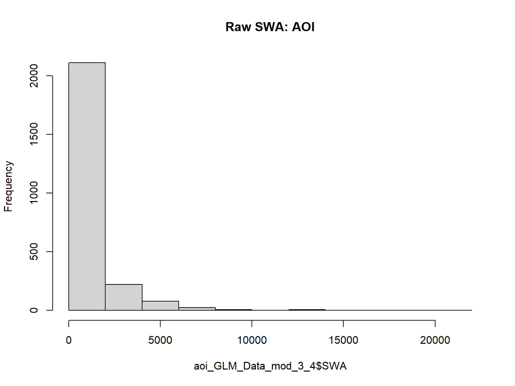

```
## [1] 787.4394
```

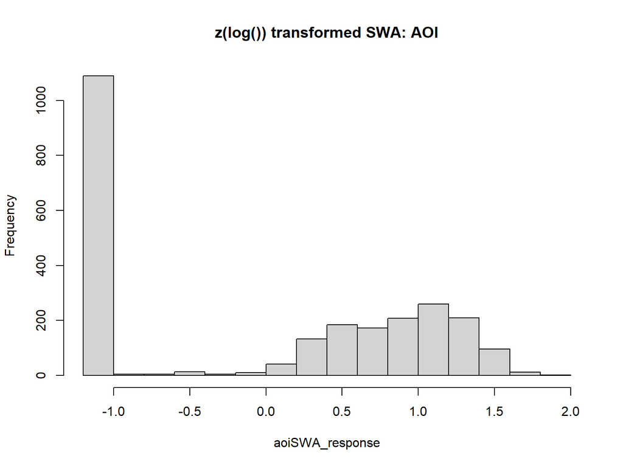

```
## [1] -7.24522e-17
```

```
## [1] 1
```

**BRAZIL**

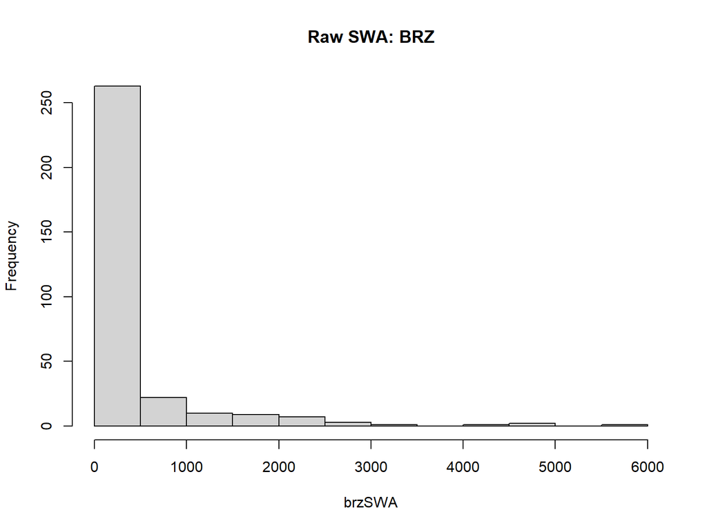

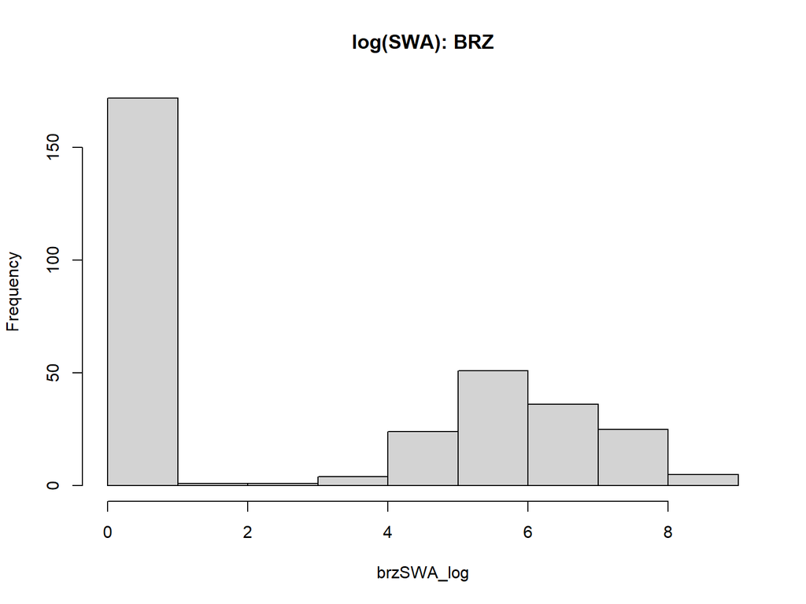

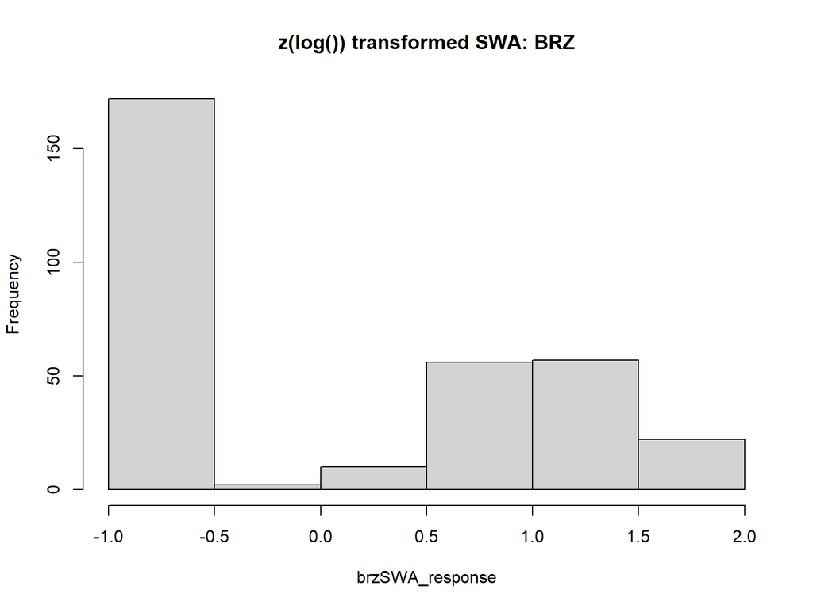

**LARB**

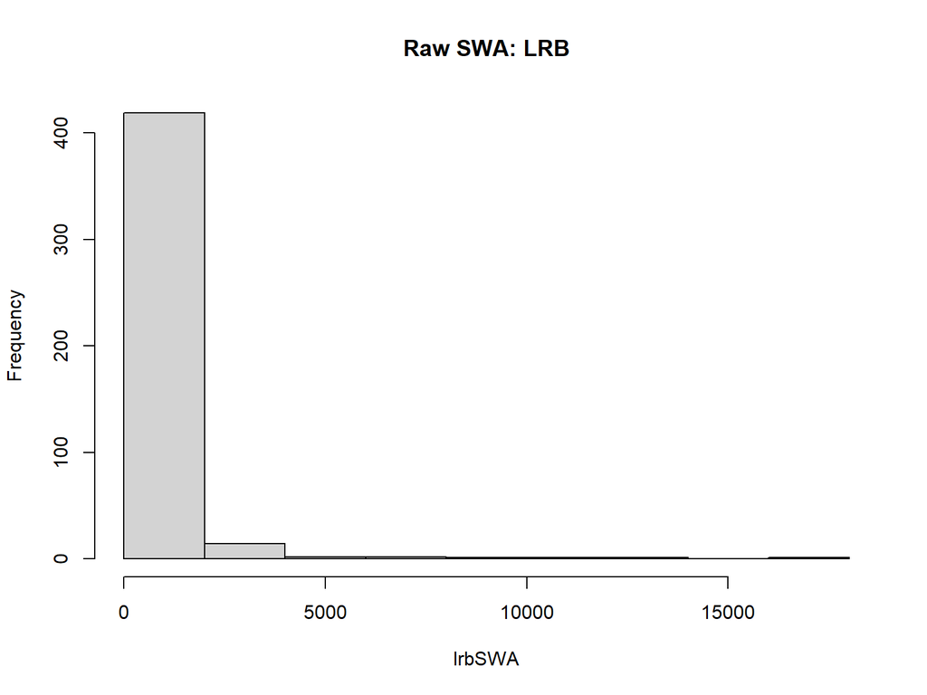

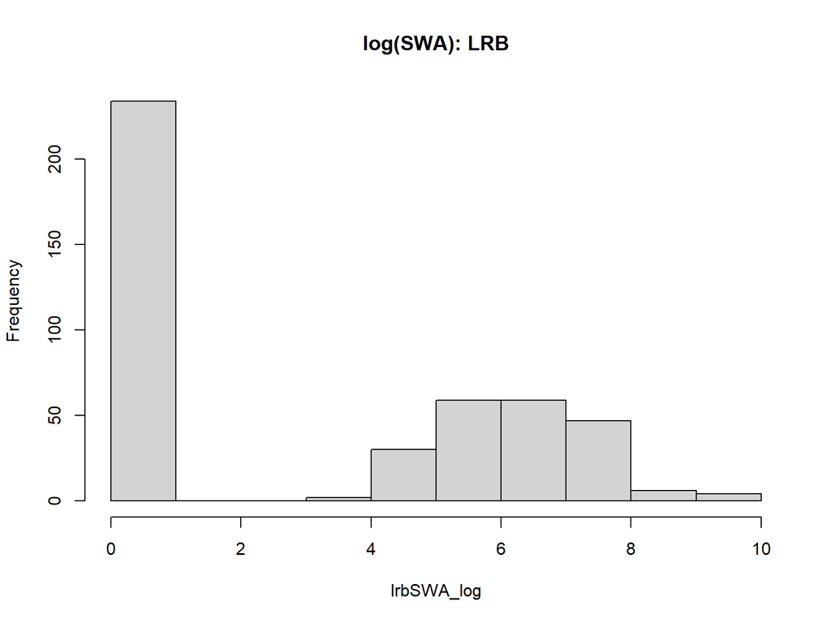

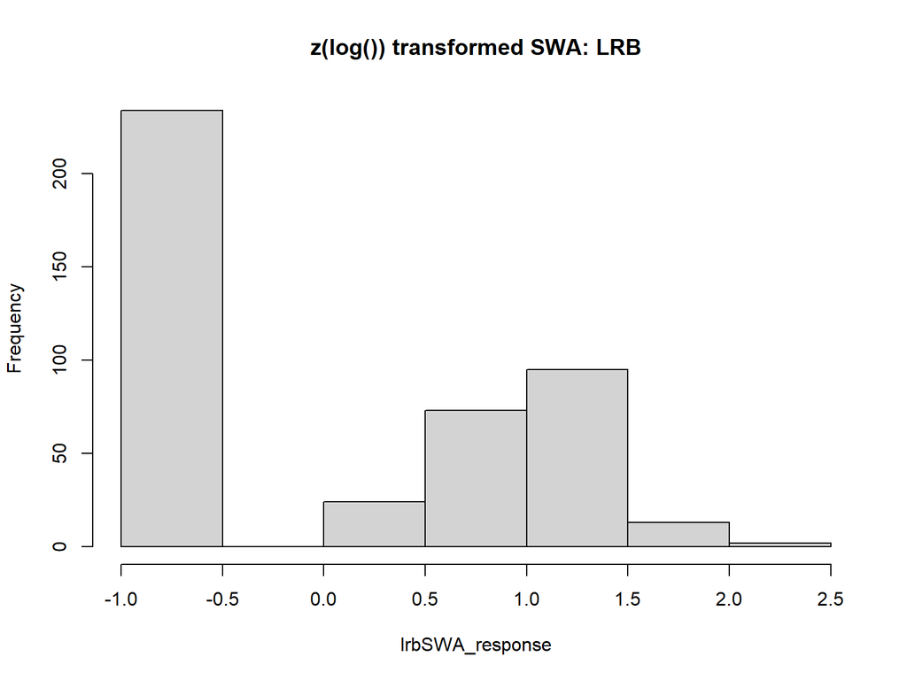

**LONE TREE**

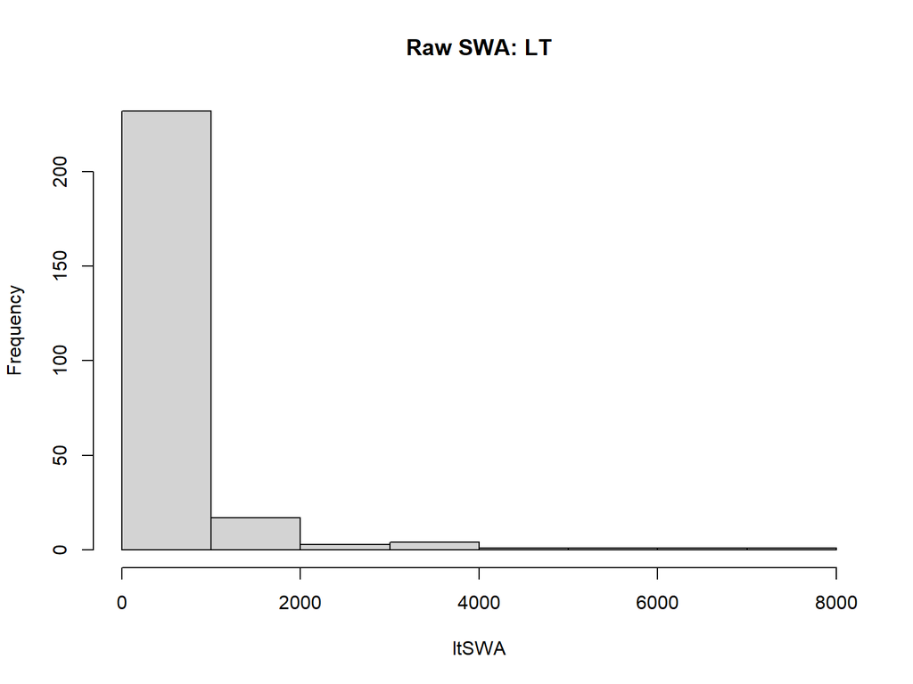

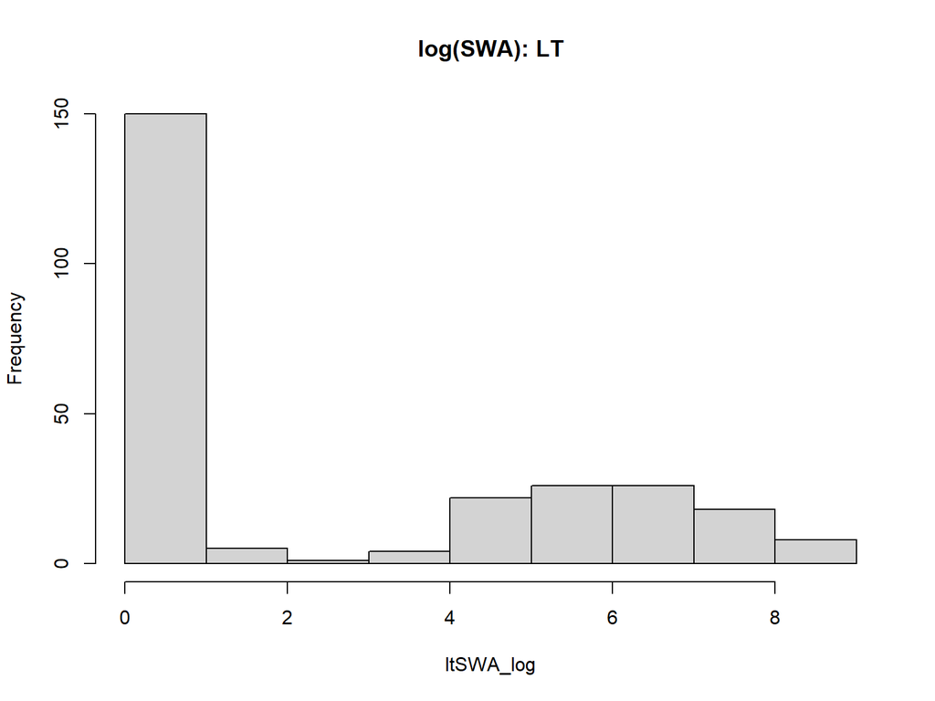

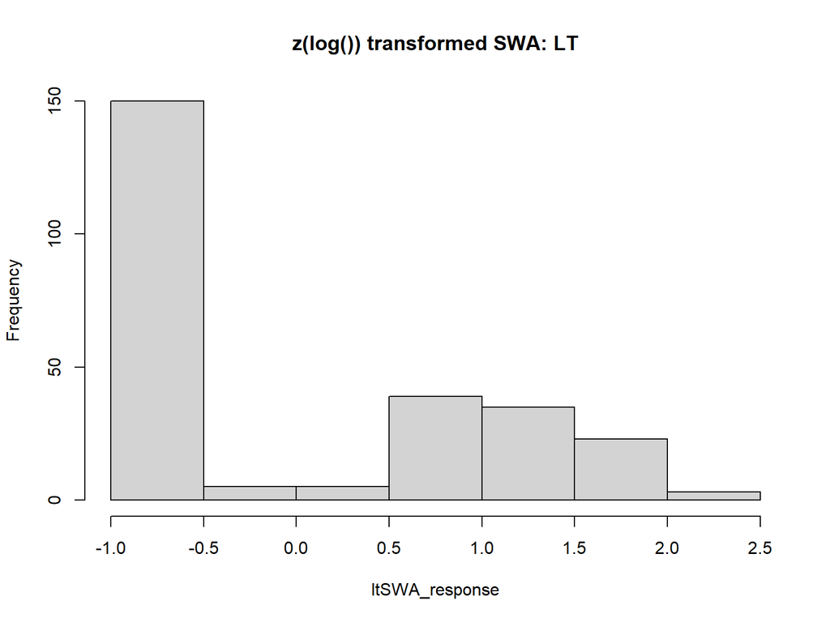

**LOWER BEAVER**

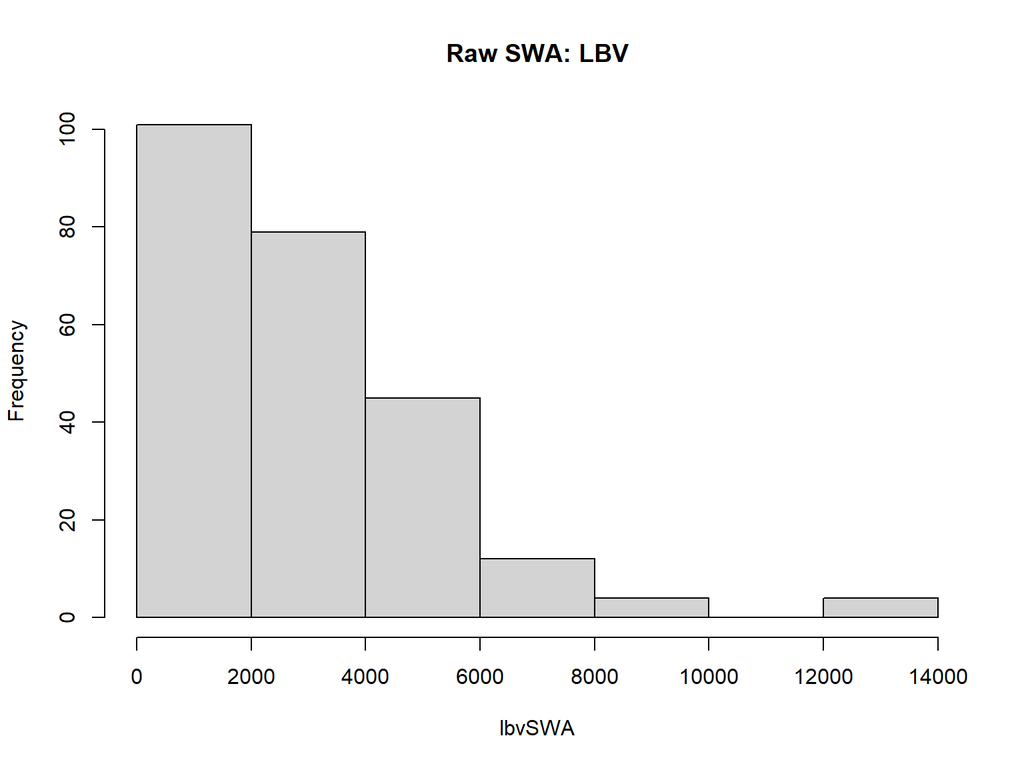

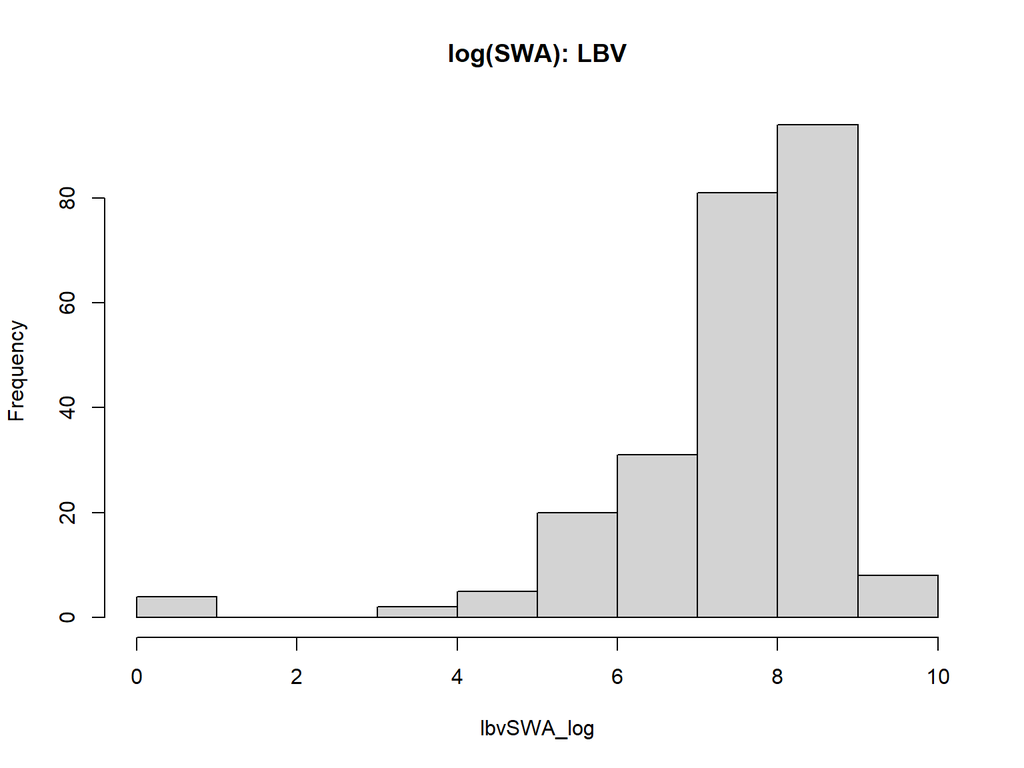

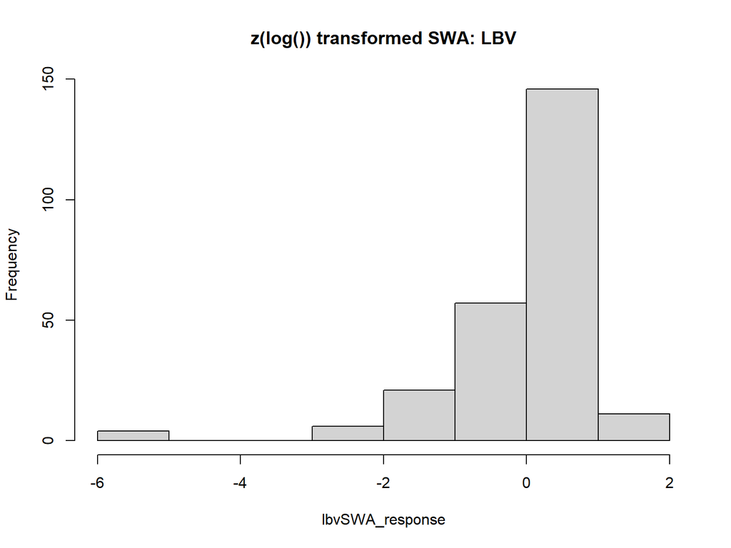

**UPPER BEAVER**

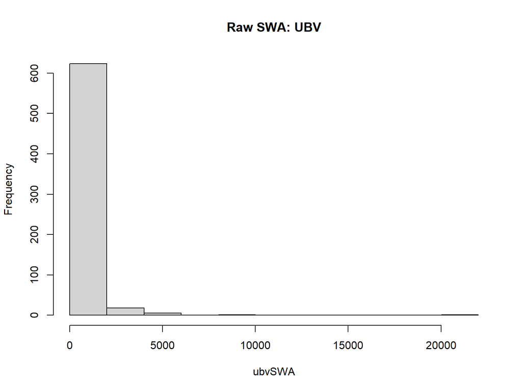

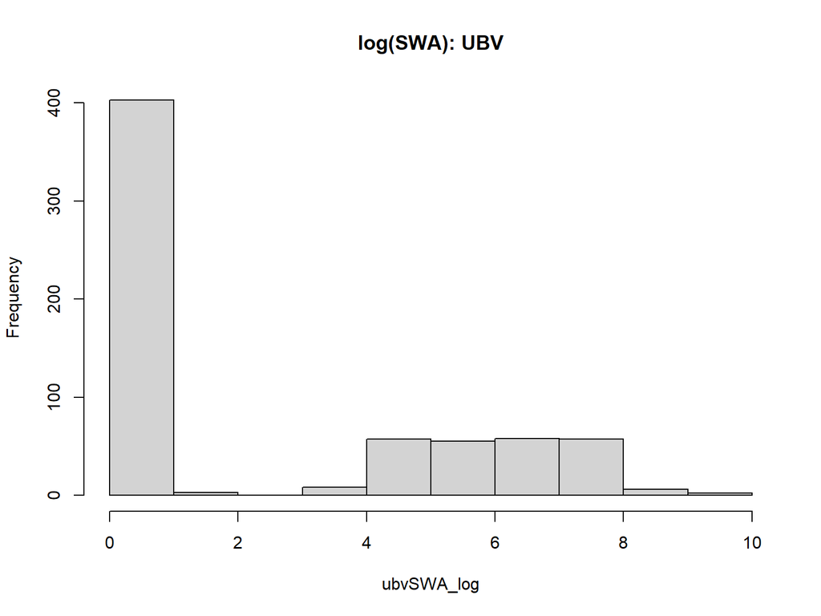

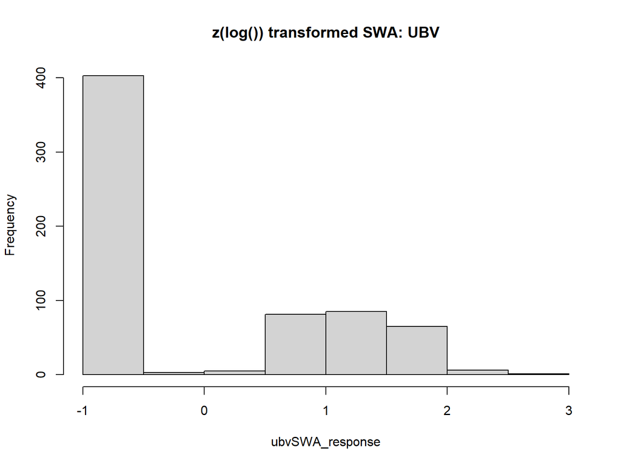

**WILLOW**

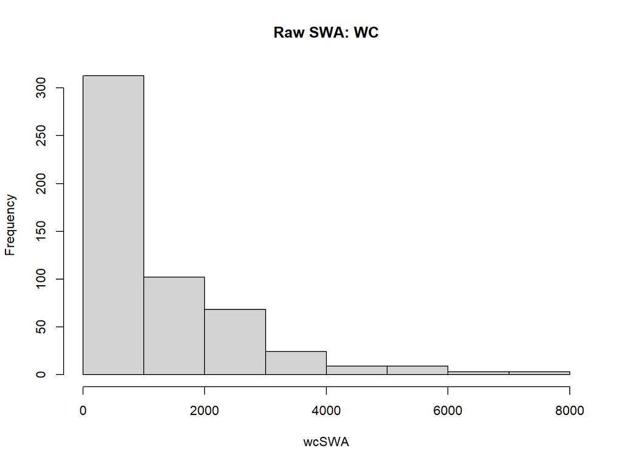

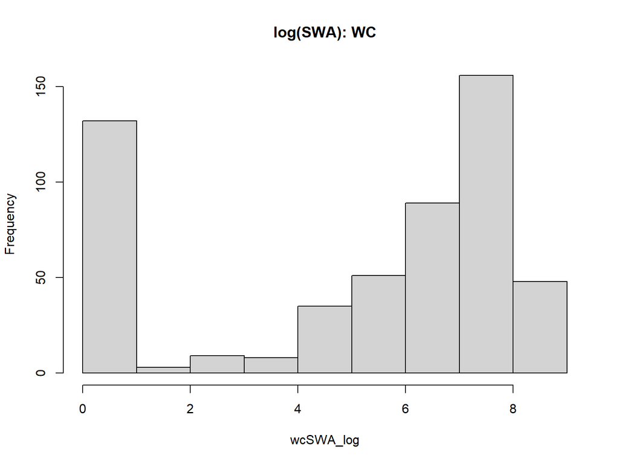

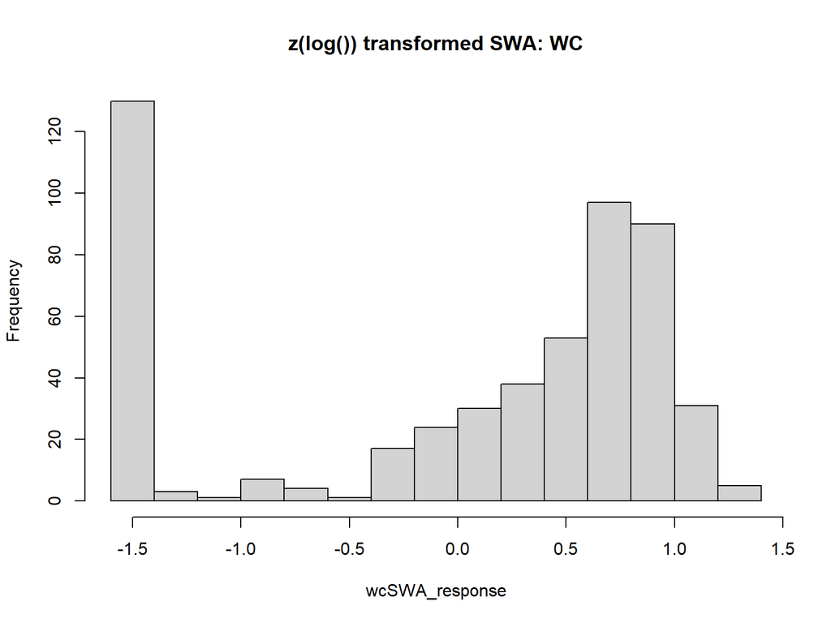

```
This section explores late summner SWA in relation to beaver dam presence.

Uses nested random slopes for beaver dam effect to allow for stream, year,
and sampleEvent to cause deviation from the global mean beaver effect.

Uses z(log(SWA)) for AOI all years.
```

## Implement HGLMMs:

## M3: Dam Presence Only; seasonal random slope (sampleEvent)

```
set.seed(12345)



Sys.time()

sink("HGLMM_damPres.jags")

cat("
model {

  for (i in 1:N) {
    SWA[i] ~ dnorm(mu[i], tau)

  mu[i] <- alpha
             + (beta1
                + b_stream[stream[i]]
                + b_year[year[i]]
                + b_event[sampleEvent[i]]) * damPresence[i]
             + eta_stream[stream[i]]
             + eta_event[sampleEvent[i]]
             + eta_cluster[clusterID[i]]
  }

  # Fixed effects (standardized log-SWA scale)
  alpha ~ dnorm(0, 1)  #mean SWA (no dam) ~ 0 +- 1 sd
  beta1 ~ dnorm(0, 1)  #dam effect ~ 0 +- 1 sd

  # Random Effects
  # Stream/Watershed
  for (j in 1:n_stream) {
    eta_stream[j] ~ dnorm(0, tau_stream)     # random intercept for stream
    b_stream[j]   ~ dnorm(0, tau_b_stream)   # random slope for stream
  }

  # Year-level dam effect
  for(yr in 1:n_year) {
    b_year[yr] ~ dnorm(0, tau_b_year)        # random slope for year
  }

```

[output cut: 21 more lines]

```
  sigma_b_year ~ dnorm(0,0.7) T(0,)
  tau_b_year <- pow(sigma_b_year, -2)

  sigma_b_event ~ dnorm(0,0.7) T(0,)
  tau_b_event <- pow(sigma_b_event, -2)

  sigma_event ~ dnorm(0,1) T(0,)
  tau_event <- pow(sigma_event, -2)

  sigma_cluster ~ dnorm(0,1) T(0,)
  tau_cluster <- pow(sigma_cluster, -2)
}
", fill = TRUE)

sink()
```

```
##
## Processing function input.......
##
## Done.
##
## Beginning parallel processing using 3 cores. Console output will be suppressed.
##
## Parallel processing completed.
##
## Calculating statistics.......
##
## Done.
```

```
## [1] "2026-07-07 10:52:14 MDT"
```

difference in sys.time = elapsed time for model to run

## M3: Prior-Posterior Overlap:

Check global intercept and global beaver effect slope

```
PRIORS FROM M3:
alpha  ~ dnorm(0, 1)
beta1  ~ dnorm(0, 1)
```

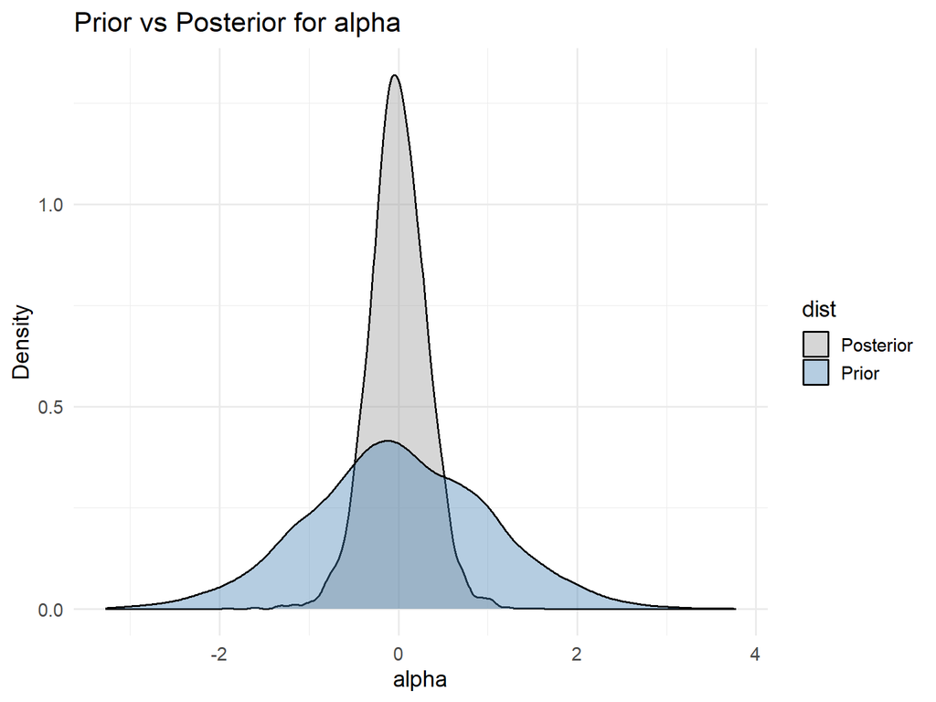

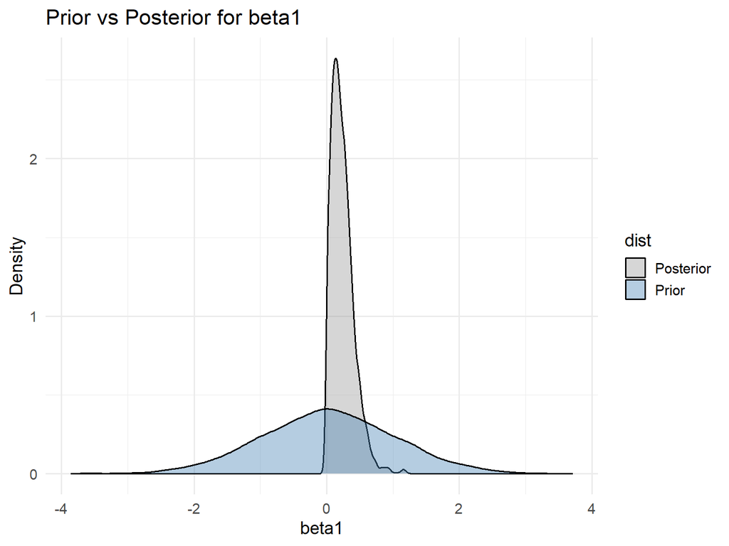

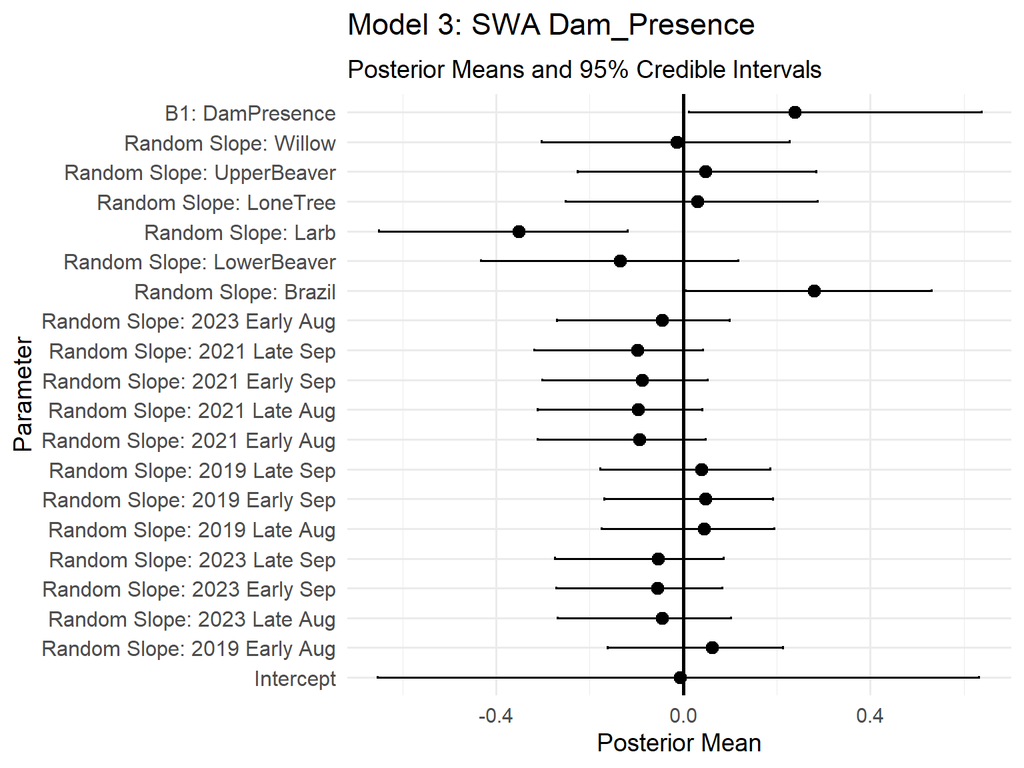

M3 posterior mean dam effect [mean(beta1)]:

```
## [1] 0.2380866
```

This is on a z-standardized log(SWA) scale ^

## —-

Compute predicted dam effects and baseline SWA conditions:

Convert from z(log(SWA)) back to SWA (m^2):

Compute “typical dam effect across watersheds and late summer sampling events”

Mean predicted dam effect for ‘typical’ stream/year/event: +- 95% CI

(m^2)

```
## [1] 241.942
```

```
##      2.5%
## -571.0065
```

```
##    97.5%
## 2167.215
```

On the raw SWA scale (m^2).

Compute global *proportional* change in SWA caused by dam presence for typical stream/year/event: +- 95% CI

```
## [1] "M3 Average proportional change from baseline caused by dam presence:"
```

```
## [1] "+- 95% CI"
```

```
## [1] 1.291028
```

```
##       2.5%
## -0.6659407
```

```
##    97.5%
## 7.341133
```

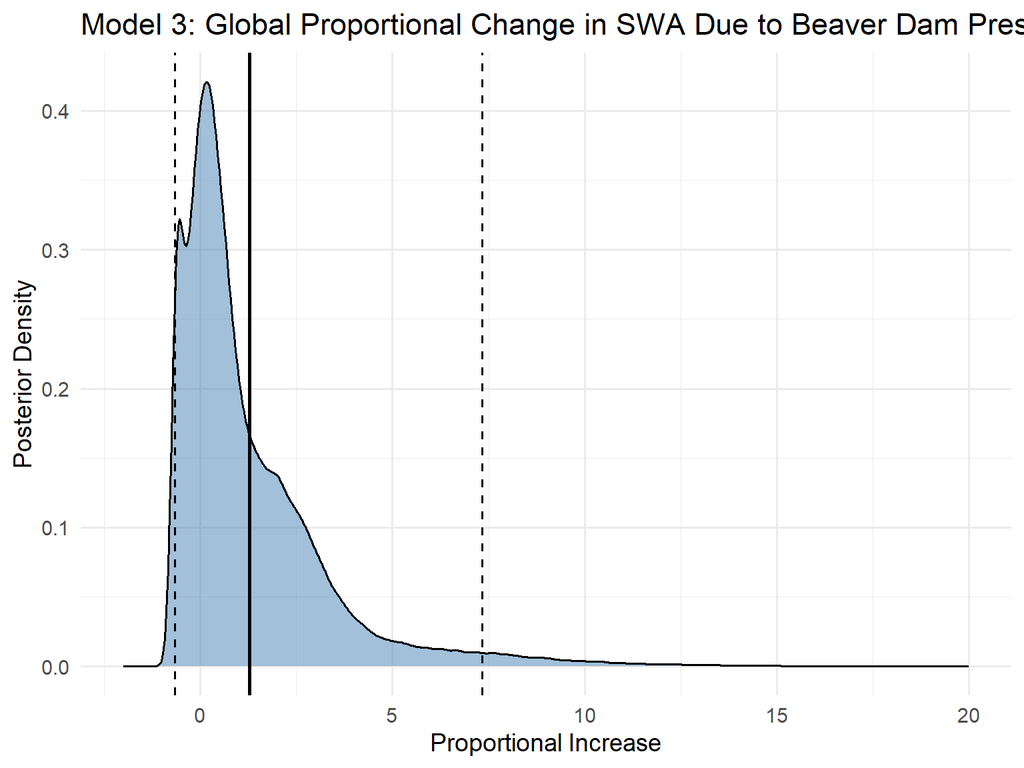

Heatmap of proportional change in SWA across watersheds and sampling events

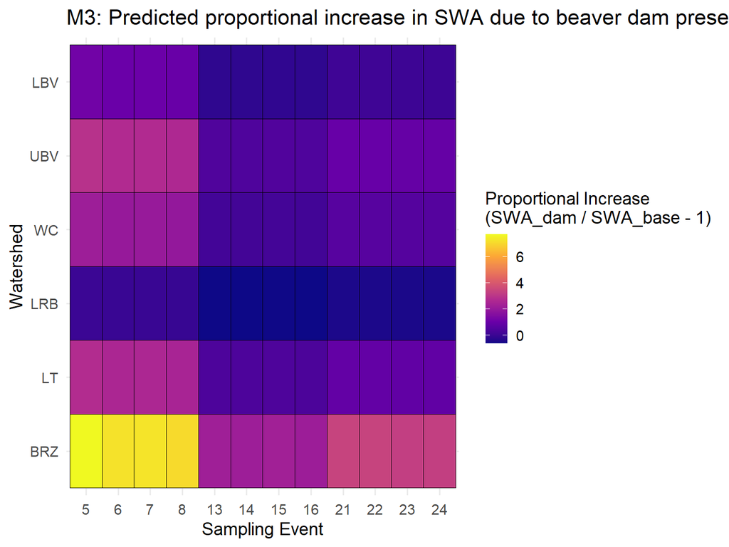

1.28 =~ 128% increase from baseline conditions

with LOTS of variation; in some cases, dammed reaches have less water than undammed. in other cases, dammed reaches have LOTS more water than un-dammed.

## —-

Compare b1 trajectory across event, by stream:

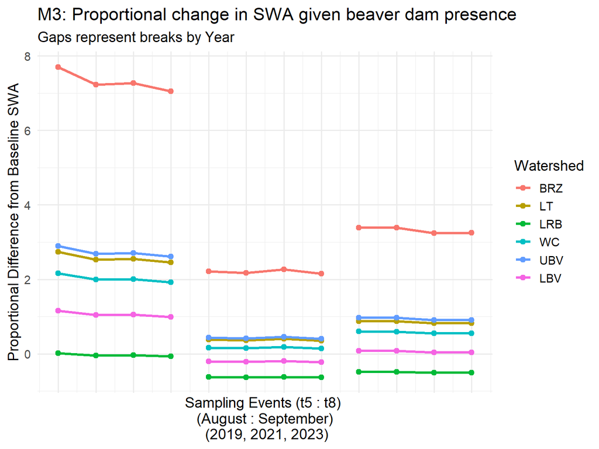

Interestingly, Brazil sees the highest proportional difference, though this is likely confounded by geomorphic conditions, and will likely change in M4.

For the most part, though, dams do seem to increase late summer surface water area to some degree, when compared to un-dammed reaches.

## **NOTE**

Structural changes between m3 and m4 shift parameter interpretations, and caution should be used in comparison.

The M3 plots presented above represent the model-estimated global dam effect, with geomorphology and drainage area effects *implicitly* included by the random effects structure. Thus, $\alpha$ is the baseline SWA with 0 dam, across all geomorphic/drainage conditions in the dataset (i.e., unconditional on geomorphology). AS a result, the ‘baseline’ conditions $(\alpha)$, and dam effects $\beta1$ are inflated because the intercept and random effects parameters are forced to account for all of the variance explained by covariates in M4.

By including z-std covariates in M4, $\alpha$ becomes “baseline SWA with 0 dam, at mean geomorphic/drainage conditions”. Further, in M4, $\beta1$ becomes the global average dam effect at mean geomorphic/drainage conditions; $[\beta_{stream}, \beta_{year}, \beta_{event}]$ represent stream/year/event deviations from that global dam effect (at mean covariate conditions).

## M4: Dam Presence + Context with updated random effects structure

```
set.seed(12345)

Sys.time()

sink("HGLMM_allCovar.jags")

cat("
    model {

  for (i in 1:N) {

  SWA[i] ~ dnorm(mu[i], tau)

  mu[i] <- alpha
             + (beta1
                + b_stream[stream[i]]
                + b_year[year[i]]
                + b_event[sampleEvent[i]]) * damPresence[i]
             + beta2 * TO[i]
             + beta3 * RIPA[i]
             + beta4 * UDA[i]
             + eta_stream[stream[i]]
             + eta_event[sampleEvent[i]]
             + eta_cluster[clusterID[i]]
  }

  # Fixed effects
  alpha ~ dnorm(0, 1)
  beta1 ~ dnorm(0, 1)
  beta2 ~ dnorm(0, 1)
  beta3 ~ dnorm(0, 1)
  beta4 ~ dnorm(0, 1)

  # Random Effects
  # Stream/Watershed
  for (j in 1:n_stream) {
    eta_stream[j] ~ dnorm(0, tau_stream)     # random intercept for stream
    b_stream[j]   ~ dnorm(0, tau_b_stream)   # random slope for stream
  }

```

[output cut: 26 more lines]

```
  sigma_b_year ~ dnorm(0, 0.7) T(0,)
  tau_b_year <- pow(sigma_b_year, -2)

  sigma_b_event ~ dnorm(0, 0.7) T(0,)
  tau_b_event <- pow(sigma_b_event, -2)

  sigma_event ~ dnorm(0, 1) T(0,)
  tau_event <- pow(sigma_event, -2)

  sigma_cluster ~ dnorm(0, 1) T(0,)
  tau_cluster <- pow(sigma_cluster, -2)
}
", fill = TRUE)

sink()
```

```
##
## Processing function input.......
##
## Done.
##
## Beginning parallel processing using 3 cores. Console output will be suppressed.
##
## Parallel processing completed.
##
## Calculating statistics.......
##
## Done.
```

```
## [1] "2026-07-07 10:53:05 MDT"
```

difference in sys.time = elapsed time for model to run

## —-

**NOTE:**

TO was transformed to “channel incision” by taking the inverse of proportion openness:

$$ChannelIncision = 1 - (TO/90)$$

Where $(TO/90)$ is the proportion of max openness (90 degrees = “flat”/“fully open”)

## —-

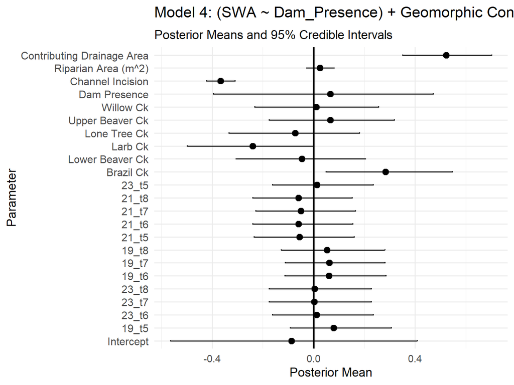

m4 Mean Dam Effect:

```
## [1] 0.06567918
```

m4 Mean TO Effect

Interpretation: z(log(SWA)) change per 1 standard deviation increase in channel incision

```
## [1] -0.3661377
```

m4 Mean RIPA Effect:

Interpretation: z(log(SWA)) change per 1 standard deviation increase in riparian area

```
## [1] 0.02500396
```

m4 Mean CDA Effect

Interpretation: z(log(SWA)) change per 1 standard deviation increase in contributing drainage area

```
## [1] 0.5219164
```

Compute “typical dam effect across watersheds and late summer sampling events”

Mean predicted dam effect for ‘typical’ stream/year/event: +- 95% CI

(m^2)

```
## [1] 62.61453
```

```
##      2.5%
## -61.61382
```

```
##   97.5%
## 612.218
```

On the raw SWA scale (m^2).

When you control for site-level differences in geomorphology and contributing drainage area, dammed reaches, for a typical stream/year/event, have ~63 m^2 *more* SWA than un-dammed reaches. Still lots of variation, though more of it is explained by geomorphology/drainage area in M4.

## —-

Estimated baseline conditions:

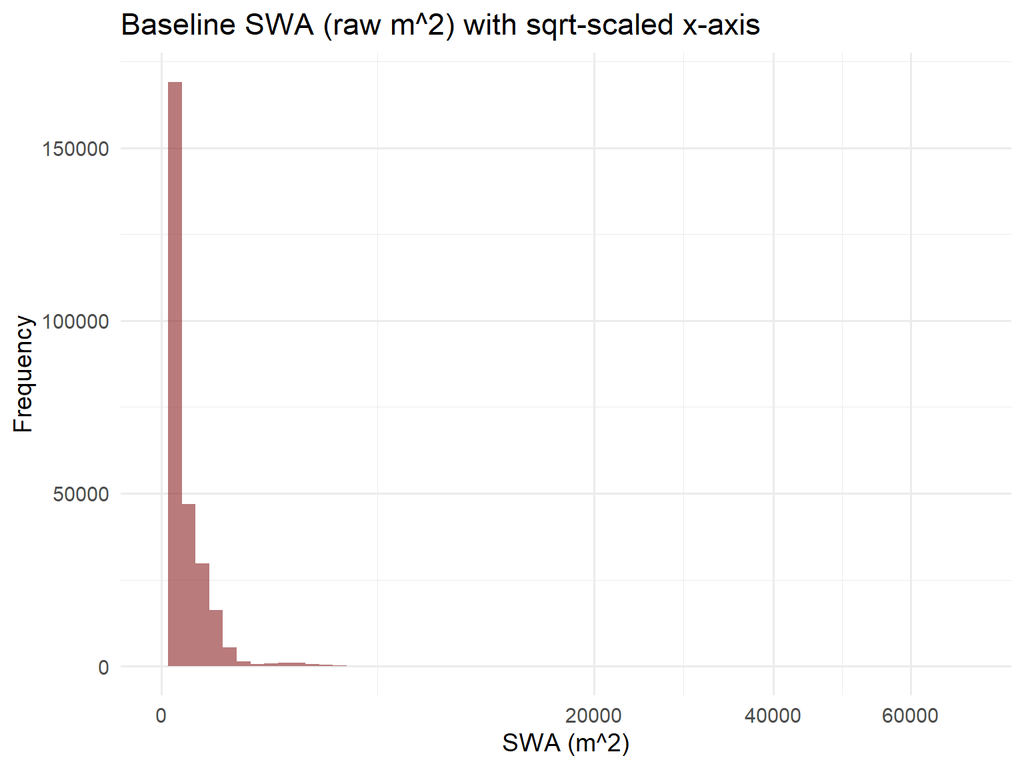

```
## [1] 91.46825
```

baseline = 92 m^2 on average

Compute global *proportional* change in SWA caused by dam presence for typical stream/year/event:

+- 95% CI

```
## [1] 0.6401228
```

```
##       2.5%
## -0.6406583
```

```
##    97.5%
## 4.370771
```

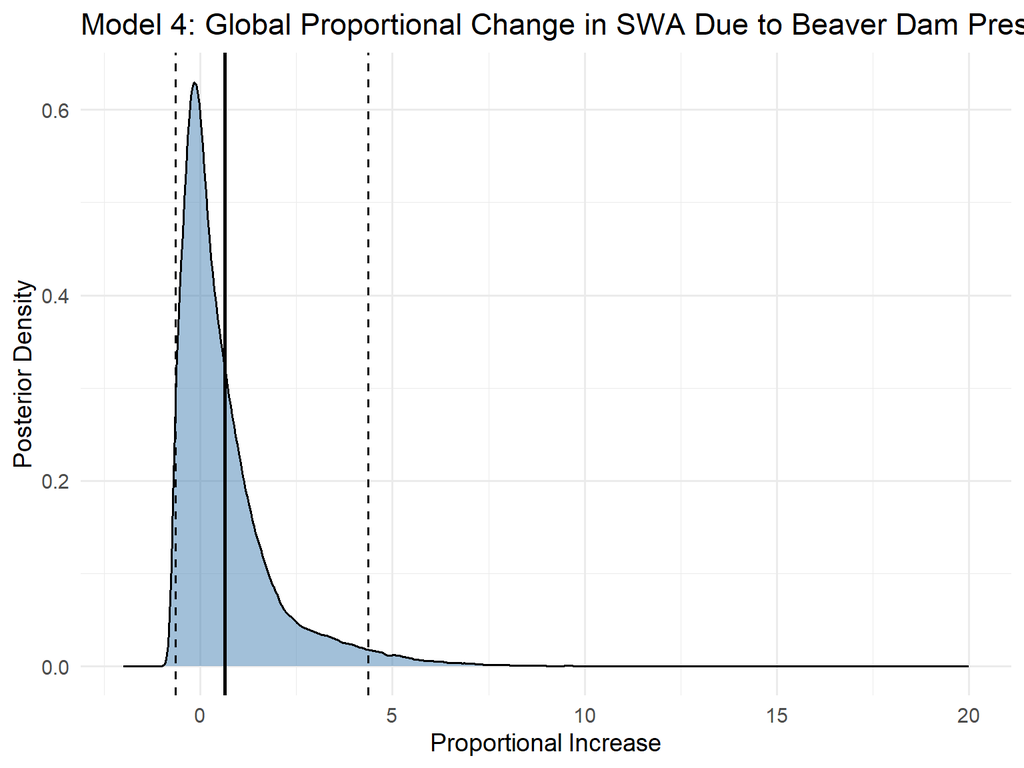

Heatmap of proportional change in SWA across watersheds and sampling events

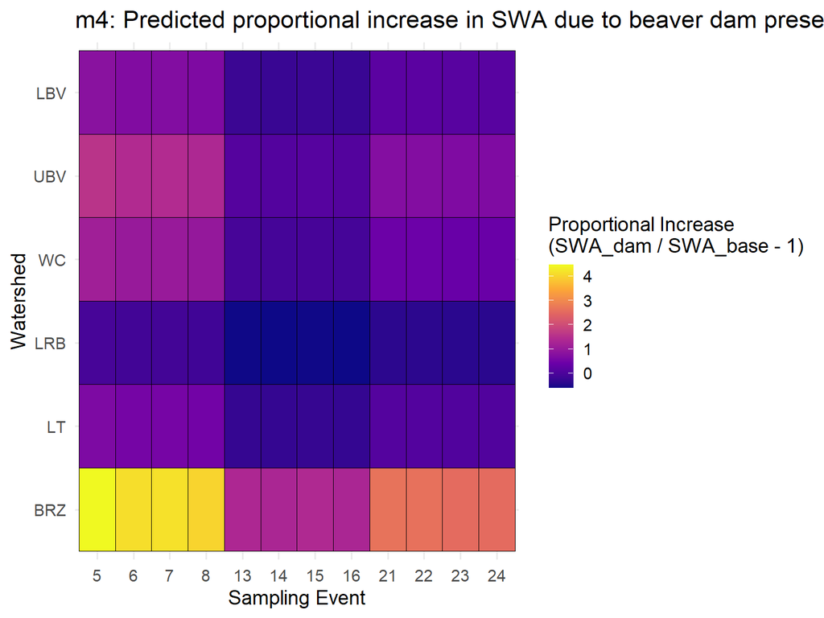

0.63 =~ 63% increase from baseline conditions

With LOTS of variation; in some cases, dammed reaches have less water than undammed. in other cases, dammed reaches have LOTS more water than un-dammed. Again, though, the scale has shifted, because more of the immense variation in SWA was explained by geomorph./drainage area.

Compare b1 trajectory across event, by stream:

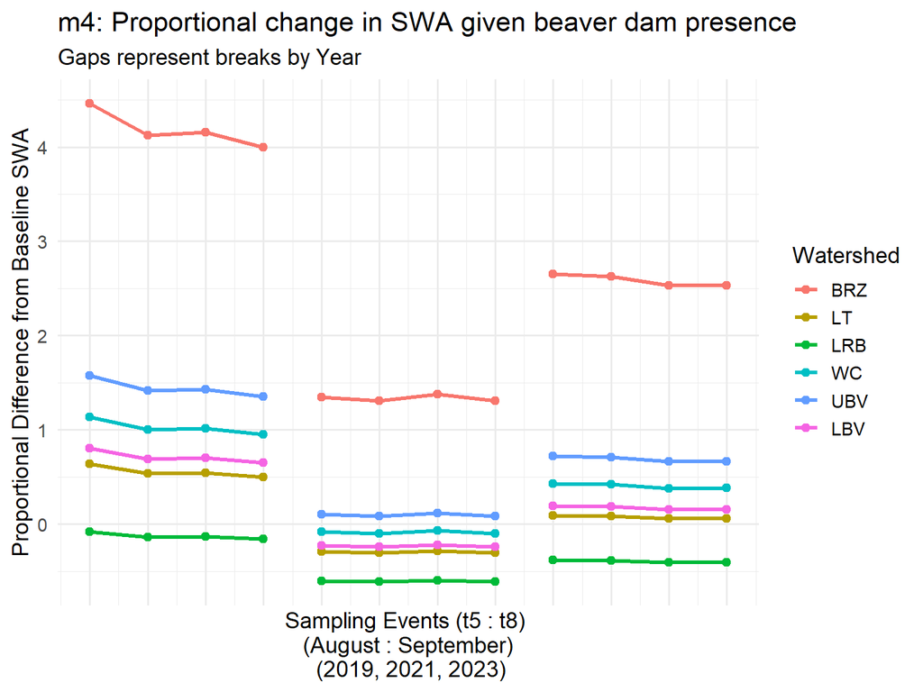

Similar patterns to M3, though a few positional changes among watersheds. *NOTE* as well, the scale change from M3 (0,8) to M4 (0, 4.5).